# Jeff_Capstone

```python
# import required libraries
import numpy as np
import pandas as pd
import matplotlib.pyplot as plt
import seaborn as sns

from sklearn.preprocessing import StandardScaler
from sklearn.model_selection import train_test_split, cross_val_score
from sklearn.metrics import mean_squared_error, r2_score
from sklearn.decomposition import PCA

from sklearn.linear_model import LinearRegression
from sklearn.ensemble import RandomForestRegressor

from statsmodels.tsa.arima.model import ARIMA
from statsmodels.tsa.stattools import adfuller
from statsmodels.tsa.seasonal import seasonal_decompose
```

```python
# Install pyreadr library
!pip install pyreadr
```

```python
# Read the data from .RDS files
import pyreadr
data =  pyreadr.read_r('2019_1min_df.RDS')
df_2019 = data[None]
data = pyreadr.read_r('2020_1min_df.RDS')
df_2020 = data[None]
data = pyreadr.read_r('2021_1min_df.RDS')
df_2021 = data[None]
data = pyreadr.read_r('2022_1min_df.RDS')
df_2022 = data[None]
data = pyreadr.read_r('2023_1min_df.RDS')
df_2023 = data[None]

# Merge all the dataframes to form one dataframe.
df = pd.concat([df_2019, df_2020, df_2021, df_2022, df_2023], ignore_index=True)
df.shape
```

```
(2629440, 10)
```

```python
df.isna().sum()
```

```
datetime_utc                           0
datetime_stamp                         0
Wells_Total_Discharge                  3
Chelan_Flow                          826
Entiat_Flow                        29756
Rocky_Reach_Total_Discharge          847
Wenatchee_Flow                        26
Rock_Island_Total_Discharge         1369
Rock_Island_Headwater_Elevation     1378
Rocky_Reach_Headwater_Elevation      893
dtype: int64
```

```python
# Fill Null Values using foward fill and backward fill
df.fillna(method='ffill', inplace=True)
df.fillna(method='bfill', inplace=True)
```

# Initial Calculations

## Rocky Reach Inflow Calculations

Rocky Reach Inflow = Wells Flow Impact + Chelan Flow Impact + Entiat Flow Impact

```python
# Convert 'datetime_utc' to datetime format
df['datetime_utc'] = pd.to_datetime(df['datetime_utc'])

# Sort DataFrame by 'datetime_utc'
df.sort_values(by='datetime_utc', inplace=True)

# Calculate Wells Flow Impact
df['Wells_Flow_Impact'] = df['Wells_Total_Discharge'].shift(105).rolling(window=16).mean()
df['Wells_Flow_Impact'].fillna(method='bfill', inplace=True)

# Calculate Chelan Flow Impact
df['Chelan_Flow_Impact'] = df['Chelan_Flow'].shift(77).rolling(window=16).mean()
df['Chelan_Flow_Impact'].fillna(method='bfill', inplace=True)

# Calculate Entiat Flow Impact
df['Entiat_Flow_Impact'] = df['Entiat_Flow'].shift(30).rolling(window=16).mean()
df['Entiat_Flow_Impact'].fillna(method='bfill', inplace=True)

# Calculate Rocky Reach Inflow
df['Rocky_Reach_Inflow'] = df['Wells_Flow_Impact'] + df['Chelan_Flow_Impact'] + df['Entiat_Flow_Impact']

# Display the updated DataFrame
df[['datetime_utc', 'Wells_Flow_Impact', 'Chelan_Flow_Impact', 'Entiat_Flow_Impact', 'Rocky_Reach_Inflow']].head()
```

|  | datetime_utc | Wells_Flow_Impact | Chelan_Flow_Impact | Entiat_Flow_Impact | Rocky_Reach_Inflow |
| --- | --- | --- | --- | --- | --- |
| 0 | 2019-01-01 08:00:00+00:00 | 56.139926 | 2.387459 | 0.0 | 58.527385 |
| 1 | 2019-01-01 08:01:00+00:00 | 56.139926 | 2.387459 | 0.0 | 58.527385 |
| 2 | 2019-01-01 08:02:00+00:00 | 56.139926 | 2.387459 | 0.0 | 58.527385 |
| 3 | 2019-01-01 08:03:00+00:00 | 56.139926 | 2.387459 | 0.0 | 58.527385 |
| 4 | 2019-01-01 08:04:00+00:00 | 56.139926 | 2.387459 | 0.0 | 58.527385 |

## Rock Island Inflow Calculation

Rock Island Inflow Calculation Rocky Reach Flow Impact = Depends on Rocky Reach Total Discharge (RRTD) at time (now) Wenatchee Flow Impact = flow from 22 minutes ago

Rocky Reach Flow Timing Logic:

If RRTD <= 50, then Rocky Reach Flow Impact = RRTD from 43 min ago

If RRTD > 50 & RRTD <= 80, then Rocky Reach Flow Impact = RRTD from 45 min ago

If RRTD > 80 & RRTD <= 120, then Rocky Reach Flow Impact = RRTD from 47 min ago

If RRTD > 120 & RRTD <= 150, then Rocky Reach Flow Impact = RRTD from 48 min ago

If RRTD > 150 & RRTD <= 220, then Rocky Reach Flow Impact = RRTD from 50 min ago

If RRTD > 220, then Rocky Reach Flow Impact = RRTD from 50 min ago

Rock Island Inflow = Rocky Reach Flow Impact + Wenatchee Flow Impact

```python
# Define the conditions and corresponding shifts
conditions = [50, 80, 120, 150, 220]
shifts = [43, 45, 47, 48, 50]

# Calculate 'Rocky_Reach_Flow_Impact' in a vectorized way
df['Rocky_Reach_Flow_Impact'] = np.select(
    [df['Rocky_Reach_Total_Discharge'] <= condition for condition in conditions],
    [df['Rocky_Reach_Total_Discharge'].shift(shift) for shift in shifts],
    default=df['Rocky_Reach_Total_Discharge'].shift(50)
)
# For starting rows
df['Rocky_Reach_Flow_Impact'].fillna(method='bfill', inplace=True)

# Calculate 'Wenatchee_Flow_Impact' with backward filling
df['Wenatchee_Flow_Impact'] = df['Wenatchee_Flow'].shift(22)
# For starting rows
df['Wenatchee_Flow_Impact'].fillna(method='bfill', inplace=True)

# Calculate 'Rock Island Inflow'
df['Rock_Island_Inflow'] = df['Rocky_Reach_Flow_Impact'] + df['Wenatchee_Flow_Impact']

# Display the updated DataFrame
df[['datetime_utc', 'Rocky_Reach_Flow_Impact', 'Wenatchee_Flow_Impact', 'Rock_Island_Inflow']].head()
```

|  | datetime_utc | Rocky_Reach_Flow_Impact | Wenatchee_Flow_Impact | Rock_Island_Inflow |
| --- | --- | --- | --- | --- |
| 0 | 2019-01-01 08:00:00+00:00 | 72.28602 | 1.823813 | 74.109834 |
| 1 | 2019-01-01 08:01:00+00:00 | 72.28602 | 1.823813 | 74.109834 |
| 2 | 2019-01-01 08:02:00+00:00 | 72.28602 | 1.823813 | 74.109834 |
| 3 | 2019-01-01 08:03:00+00:00 | 72.28602 | 1.823813 | 74.109834 |
| 4 | 2019-01-01 08:04:00+00:00 | 72.28602 | 1.823813 | 74.109834 |

# Fill Rate

```python
# Calculate fill rate at both dams
df['Rocky_Reach_Fill_Rate'] = df['Rocky_Reach_Inflow'] - df['Rocky_Reach_Total_Discharge']
df['Rock_Island_Fill_Rate'] = df['Rock_Island_Inflow'] - df['Rock_Island_Total_Discharge']

# Display the updated DataFrame
df[['Rocky_Reach_Fill_Rate','Rock_Island_Fill_Rate']].head()
```

|  | Rocky_Reach_Fill_Rate | Rock_Island_Fill_Rate |
| --- | --- | --- |
| 0 | -13.758636 | -21.462003 |
| 1 | -10.294244 | -21.565912 |
| 2 | -7.975250 | -19.918337 |
| 3 | -5.349238 | -18.965717 |
| 4 | -3.843683 | -19.507878 |

# Headwater Elevation Change Vs Fill Rate

```python
# Calculate the change in Rocky Reach headwater elevation
df['Rocky_Reach_Headwater_Elevation_Change'] = df['Rocky_Reach_Headwater_Elevation'].diff()
df['Rocky_Reach_Headwater_Elevation_Change'].fillna(method='ffill', inplace=True)
df['Rocky_Reach_Headwater_Elevation_Change'].fillna(method='bfill', inplace=True)

# Calculate the correlation between Rocky Reach Fill Rate and Headwater Elevation Change
rocky_reach_correlation = df['Rocky_Reach_Fill_Rate'].corr(df['Rocky_Reach_Headwater_Elevation_Change'])
print(f'Correlation between Rocky Reach Fill Rate and Headwater Elevation Change: {rocky_reach_correlation}')
```

```
Correlation between Rocky Reach Fill Rate and Headwater Elevation Change: 0.04955411341279846
```

```
Mean Squared Error for Rocky Reach Dam: 0.0014435770028041143
R-squared for Rocky Reach Dam: 0.002458186592186884
```

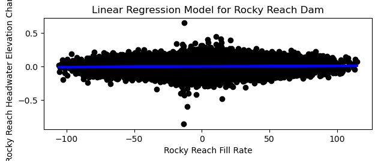

```python
# Prepare data for modeling for Rocky Reach Dam
X_rocky_reach = df[['Rocky_Reach_Fill_Rate']]
y_rocky_reach = df['Rocky_Reach_Headwater_Elevation_Change']

# Split the data into training and testing sets
X_train_rocky_reach, X_test_rocky_reach, y_train_rocky_reach, y_test_rocky_reach = train_test_split(
    X_rocky_reach, y_rocky_reach, test_size=0.2, random_state=42
)

# Create a linear regression model for Rocky Reach Dam
model_rocky_reach = LinearRegression()

# Train the model for Rocky Reach Dam
model_rocky_reach.fit(X_train_rocky_reach, y_train_rocky_reach)

# Make predictions on the test set for Rocky Reach Dam
y_pred_rocky_reach = model_rocky_reach.predict(X_test_rocky_reach)

# Evaluate the model for Rocky Reach Dam
mse_rocky_reach = mean_squared_error(y_test_rocky_reach, y_pred_rocky_reach)
r2_rocky_reach = r2_score(y_test_rocky_reach, y_pred_rocky_reach)

print(f'Mean Squared Error for Rocky Reach Dam: {mse_rocky_reach}')
print(f'R-squared for Rocky Reach Dam: {r2_rocky_reach}')

# Plot the regression line for Rocky Reach Dam
plt.subplot(2, 1, 2)
plt.scatter(X_test_rocky_reach, y_test_rocky_reach, color='black')
plt.plot(X_test_rocky_reach, y_pred_rocky_reach, color='blue', linewidth=3)
plt.title('Linear Regression Model for Rocky Reach Dam')
plt.xlabel('Rocky Reach Fill Rate')
plt.ylabel('Rocky Reach Headwater Elevation Change')

plt.tight_layout()
plt.show()
```

# Calculate the change in headwater elevation

```python
# Calculate the change in headwater elevation
df['Rock_Island_Headwater_Elevation_Change'] = df['Rock_Island_Headwater_Elevation'].diff()
df['Rock_Island_Headwater_Elevation_Change'].fillna(method='ffill', inplace=True)
df['Rock_Island_Headwater_Elevation_Change'].fillna(method='bfill', inplace=True)
# Calculate the correlation between Fill Rate and Headwater Elevation Change
correlation = df['Rock_Island_Fill_Rate'].corr(df['Rock_Island_Headwater_Elevation_Change'])
print(f'Correlation between Rock Island Fill Rate and Headwater Elevation Change: {correlation}')
```

```
Correlation between Rock Island Fill Rate and Headwater Elevation Change: 0.33510182202884853
```

```
Mean Squared Error for Rock Island Dam: 0.0004275305873779543
R-squared for Rock Island Dam: 0.11345380597547883
```

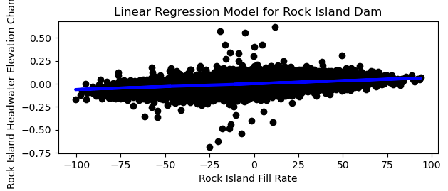

```python
# Prepare data for modeling for Rock Island Dam
X_rock_island = df[['Rock_Island_Fill_Rate']]
y_rock_island = df['Rock_Island_Headwater_Elevation_Change']

# Split the data into training and testing sets
X_train_rock_island, X_test_rock_island, y_train_rock_island, y_test_rock_island = train_test_split(
    X_rock_island, y_rock_island, test_size=0.2, random_state=42
)

# Create a linear regression model for Rock Island Dam
model_rock_island = LinearRegression()

# Train the model for Rock Island Dam
model_rock_island.fit(X_train_rock_island, y_train_rock_island)

# Make predictions on the test set for Rock Island Dam
y_pred_rock_island = model_rock_island.predict(X_test_rock_island)

# Evaluate the model for Rock Island Dam
mse_rock_island = mean_squared_error(y_test_rock_island, y_pred_rock_island)
r2_rock_island = r2_score(y_test_rock_island, y_pred_rock_island)

print(f'Mean Squared Error for Rock Island Dam: {mse_rock_island}')
print(f'R-squared for Rock Island Dam: {r2_rock_island}')

# Plot the regression line for Rock Island Dam
plt.subplot(2, 1, 2)
plt.scatter(X_test_rock_island, y_test_rock_island, color='black')
plt.plot(X_test_rock_island, y_pred_rock_island, color='blue', linewidth=3)
plt.title('Linear Regression Model for Rock Island Dam')
plt.xlabel('Rock Island Fill Rate')
plt.ylabel('Rock Island Headwater Elevation Change')

plt.tight_layout()
plt.show()
```

# Modeling2 - PCA

```python
# Read the data from .RDS files
import pyreadr
data =  pyreadr.read_r('2019_1min_df.RDS')
df_2019 = data[None]
data = pyreadr.read_r('2020_1min_df.RDS')
df_2020 = data[None]
data = pyreadr.read_r('2021_1min_df.RDS')
df_2021 = data[None]
data = pyreadr.read_r('2022_1min_df.RDS')
df_2022 = data[None]
data = pyreadr.read_r('2023_1min_df.RDS')
df_2023 = data[None]

# Merge all the dataframes to form one dataframe.
df = pd.concat([df_2019, df_2020, df_2021, df_2022, df_2023], ignore_index=True)
df['datetime_utc'] = pd.to_datetime(df['datetime_utc'])
df.sort_values(by='datetime_utc', inplace=True)

# Fill Null Values using foward fill and backward fill
df.fillna(method='ffill', inplace=True)
df.fillna(method='bfill', inplace=True)
```

```python
df.columns
```

```
Index(['datetime_utc', 'datetime_stamp', 'Wells_Total_Discharge',
       'Chelan_Flow', 'Entiat_Flow', 'Rocky_Reach_Total_Discharge',
       'Wenatchee_Flow', 'Rock_Island_Total_Discharge',
       'Rock_Island_Headwater_Elevation', 'Rocky_Reach_Headwater_Elevation'],
      dtype='object')
```

# Rocky Reach

## Data Processing and Feature Selection

```python
# Rocky Reach Headwater Elevation lag for last 2 minutes
# for lag in range(1, 3):
#   df[f'Rocky_Reach_Headwater_Elevation_lag_{lag}'] = df['Rocky_Reach_Headwater_Elevation'].shift(lag)

# # Rocky Reach Discharge lag for last 2 minutes
# for lag in range(1, 3):
#   df[f'Rocky_Reach_Total_Discharge_lag_{lag}'] = df['Rocky_Reach_Total_Discharge'].shift(lag)

# # Wells Flow Impact = flows averaged from previous 90-105 minutes
# for lag in range(90,106):
#   df[f'Wells_Total_Discharge_lag_{lag}'] = df['Wells_Total_Discharge'].shift(lag)

# # Chelan Flow Impact = flows averaged from previous 62-77 minutes (60-75 should be fine)
# for lag in range(62, 78):
#   df[f'Chelan_Flow_lag_{lag}'] = df['Chelan_Flow'].shift(lag)

# # Entiat Flow Impact = flows averaged from previous 15-30 minutes
# for lag in range(15, 31):
#   df[f'Entiat_Flow_lag_{lag}'] = df['Entiat_Flow'].shift(lag)

# df.columns
```

[output not shown]

```python
# Resample the data into 45-minute intervals and calculate the mean
df_resampled = df.set_index('datetime_utc').resample('45T').mean().reset_index()

# Add lag features to the resampled dataframe
for lag in range(1, 3):
    df_resampled[f'Rocky_Reach_Headwater_Elevation_lag_{lag}'] = df_resampled['Rocky_Reach_Headwater_Elevation'].shift(lag)

for lag in range(1, 3):
    df_resampled[f'Rocky_Reach_Total_Discharge_lag_{lag}'] = df_resampled['Rocky_Reach_Total_Discharge'].shift(lag)

for lag in range(90, 106):
    df_resampled[f'Wells_Total_Discharge_lag_{lag}'] = df_resampled['Wells_Total_Discharge'].shift(lag)

for lag in range(62, 78):
    df_resampled[f'Chelan_Flow_lag_{lag}'] = df_resampled['Chelan_Flow'].shift(lag)

for lag in range(15, 31):
    df_resampled[f'Entiat_Flow_lag_{lag}'] = df_resampled['Entiat_Flow'].shift(lag)

df_resampled.columns
```

```
Index(['datetime_utc', 'datetime_stamp', 'Wells_Total_Discharge',
       'Chelan_Flow', 'Entiat_Flow', 'Rocky_Reach_Total_Discharge',
       'Wenatchee_Flow', 'Rock_Island_Total_Discharge',
       'Rock_Island_Headwater_Elevation', 'Rocky_Reach_Headwater_Elevation',
       'Rocky_Reach_Headwater_Elevation_lag_1',
       'Rocky_Reach_Headwater_Elevation_lag_2',
       'Rocky_Reach_Total_Discharge_lag_1',
       'Rocky_Reach_Total_Discharge_lag_2', 'Wells_Total_Discharge_lag_90',
       'Wells_Total_Discharge_lag_91', 'Wells_Total_Discharge_lag_92',
       'Wells_Total_Discharge_lag_93', 'Wells_Total_Discharge_lag_94',
       'Wells_Total_Discharge_lag_95', 'Wells_Total_Discharge_lag_96',
       'Wells_Total_Discharge_lag_97', 'Wells_Total_Discharge_lag_98',
       'Wells_Total_Discharge_lag_99', 'Wells_Total_Discharge_lag_100',
       'Wells_Total_Discharge_lag_101', 'Wells_Total_Discharge_lag_102',
       'Wells_Total_Discharge_lag_103', 'Wells_Total_Discharge_lag_104',
       'Wells_Total_Discharge_lag_105', 'Chelan_Flow_lag_62',
       'Chelan_Flow_lag_63', 'Chelan_Flow_lag_64', 'Chelan_Flow_lag_65',
       'Chelan_Flow_lag_66', 'Chelan_Flow_lag_67', 'Chelan_Flow_lag_68',
       'Chelan_Flow_lag_69', 'Chelan_Flow_lag_70', 'Chelan_Flow_lag_71',
       'Chelan_Flow_lag_72', 'Chelan_Flow_lag_73', 'Chelan_Flow_lag_74',
       'Chelan_Flow_lag_75', 'Chelan_Flow_lag_76', 'Chelan_Flow_lag_77',
       'Entiat_Flow_lag_15', 'Entiat_Flow_lag_16', 'Entiat_Flow_lag_17',
       'Entiat_Flow_lag_18', 'Entiat_Flow_lag_19', 'Entiat_Flow_lag_20',
       'Entiat_Flow_lag_21', 'Entiat_Flow_lag_22', 'Entiat_Flow_lag_23',
       'Entiat_Flow_lag_24', 'Entiat_Flow_lag_25', 'Entiat_Flow_lag_26',
       'Entiat_Flow_lag_27', 'Entiat_Flow_lag_28', 'Entiat_Flow_lag_29',
       'Entiat_Flow_lag_30'],
      dtype='object')
```

Headwater Elevation Change vs. Fill Rate

```python
# Calculate the change in Rocky Reach headwater elevation
df_resampled['Rocky_Reach_Headwater_Elevation_Change'] = df_resampled['Rocky_Reach_Headwater_Elevation'].diff()
df_resampled['Rocky_Reach_Headwater_Elevation_Change'].fillna(method='ffill', inplace=True)
df_resampled['Rocky_Reach_Headwater_Elevation_Change'].fillna(method='bfill', inplace=True)

# Calculate the correlation between Rocky Reach Fill Rate and Headwater Elevation Change
rocky_reach_correlation = df_resampled['Rocky_Reach_Fill_Rate'].corr(df_resampled['Rocky_Reach_Headwater_Elevation_Change'])
print(f'Correlation between Rocky Reach Fill Rate and Headwater Elevation Change: {rocky_reach_correlation}')

# Prepare data for modeling for Rocky Reach Dam
X_rocky_reach = df_resampled[['Rocky_Reach_Fill_Rate']]
y_rocky_reach = df_resampled['Rocky_Reach_Headwater_Elevation_Change']

# Split the data into training and testing sets
X_train_rocky_reach, X_test_rocky_reach, y_train_rocky_reach, y_test_rocky_reach = train_test_split(
    X_rocky_reach, y_rocky_reach, test_size=0.2, random_state=42
)

# Create a linear regression model for Rocky Reach Dam
model_rocky_reach = LinearRegression()

# Train the model for Rocky Reach Dam
model_rocky_reach.fit(X_train_rocky_reach, y_train_rocky_reach)

# Make predictions on the test set for Rocky Reach Dam
y_pred_rocky_reach = model_rocky_reach.predict(X_test_rocky_reach)

# Evaluate the model for Rocky Reach Dam
mse_rocky_reach = mean_squared_error(y_test_rocky_reach, y_pred_rocky_reach)
r2_rocky_reach = r2_score(y_test_rocky_reach, y_pred_rocky_reach)

print(f'Mean Squared Error for Rocky Reach Dam: {mse_rocky_reach}')
print(f'R-squared for Rocky Reach Dam: {r2_rocky_reach}')

# Plot the regression line for Rocky Reach Dam
plt.subplot(2, 1, 2)
plt.scatter(X_test_rocky_reach, y_test_rocky_reach, color='black')
plt.plot(X_test_rocky_reach, y_pred_rocky_reach, color='blue', linewidth=3)
plt.title('Linear Regression Model for Rocky Reach Dam')
plt.xlabel('Rocky Reach Fill Rate')
plt.ylabel('Rocky Reach Headwater Elevation Change')

plt.tight_layout()
plt.show()
```

[output not shown]

## Resampling data for 45-min intervals

```python
# Include only the necessary columns
df_rr = df_resampled[['datetime_utc', 'datetime_stamp', 'Wells_Total_Discharge',
       'Chelan_Flow', 'Entiat_Flow', 'Rocky_Reach_Total_Discharge',
       'Wenatchee_Flow', 'Rock_Island_Total_Discharge',
       'Rock_Island_Headwater_Elevation', 'Rocky_Reach_Headwater_Elevation',
       'Rocky_Reach_Headwater_Elevation_lag_1',
       'Rocky_Reach_Headwater_Elevation_lag_2',
       'Rocky_Reach_Total_Discharge_lag_1',
       'Rocky_Reach_Total_Discharge_lag_2', 'Wells_Total_Discharge_lag_90',
       'Wells_Total_Discharge_lag_91', 'Wells_Total_Discharge_lag_92',
       'Wells_Total_Discharge_lag_93', 'Wells_Total_Discharge_lag_94',
       'Wells_Total_Discharge_lag_95', 'Wells_Total_Discharge_lag_96',
       'Wells_Total_Discharge_lag_97', 'Wells_Total_Discharge_lag_98',
       'Wells_Total_Discharge_lag_99', 'Wells_Total_Discharge_lag_100',
       'Wells_Total_Discharge_lag_101', 'Wells_Total_Discharge_lag_102',
       'Wells_Total_Discharge_lag_103', 'Wells_Total_Discharge_lag_104',
       'Wells_Total_Discharge_lag_105', 'Chelan_Flow_lag_62',
       'Chelan_Flow_lag_63', 'Chelan_Flow_lag_64', 'Chelan_Flow_lag_65',
       'Chelan_Flow_lag_66', 'Chelan_Flow_lag_67', 'Chelan_Flow_lag_68',
       'Chelan_Flow_lag_69', 'Chelan_Flow_lag_70', 'Chelan_Flow_lag_71',
       'Chelan_Flow_lag_72', 'Chelan_Flow_lag_73', 'Chelan_Flow_lag_74',
       'Chelan_Flow_lag_75', 'Chelan_Flow_lag_76', 'Chelan_Flow_lag_77',
       'Entiat_Flow_lag_15', 'Entiat_Flow_lag_16', 'Entiat_Flow_lag_17',
       'Entiat_Flow_lag_18', 'Entiat_Flow_lag_19', 'Entiat_Flow_lag_20',
       'Entiat_Flow_lag_21', 'Entiat_Flow_lag_22', 'Entiat_Flow_lag_23',
       'Entiat_Flow_lag_24', 'Entiat_Flow_lag_25', 'Entiat_Flow_lag_26',
       'Entiat_Flow_lag_27', 'Entiat_Flow_lag_28', 'Entiat_Flow_lag_29',
       'Entiat_Flow_lag_30']]

df_rr.dropna(inplace = True)
```

```python
df_rr.shape
```

```
(58328, 62)
```

```python
# Check for non-numeric columns
non_numeric_cols = df_rr.select_dtypes(exclude=['number']).columns
print(f"Non-numeric columns: {non_numeric_cols}")

# Separate features and target
target = 'Rocky_Reach_Headwater_Elevation'
X = df_rr.drop(columns=[target])
y = df_rr[target]  # Target

# Standardize the numeric features
numeric_cols = X.select_dtypes(include=['number']).columns
scaler = StandardScaler()
X[numeric_cols] = scaler.fit_transform(X[numeric_cols])
```

```
Non-numeric columns: Index(['datetime_utc', 'datetime_stamp'], dtype='object')
```

```python
# Exclude non-numeric columns, including 'datetime_utc'
non_numeric_cols = ['datetime_utc']  # Add other non-numeric columns if needed
X_numeric = X.drop(columns=non_numeric_cols)

# Convert remaining columns to numeric
X_numeric = X_numeric.apply(pd.to_numeric, errors='coerce')

# Drop any rows with NaN values
X_numeric.dropna(inplace=True)

# Apply PCA
pca = PCA(n_components=10)
X_pca = pca.fit_transform(X_numeric)

# Splitting the data into train and test sets
X_train, X_test, y_train, y_test = train_test_split(X_pca, y, test_size=0.3, shuffle=False)

# Model training with Linear Regression
model = LinearRegression()
model.fit(X_train, y_train)

# Predictions and evaluation
y_pred = model.predict(X_test)
print("Mean Squared Error for Rocky Reach Dam:", mean_squared_error(y_test, y_pred))
print("R-Squared for Rocky Reach Dam:", r2_score(y_test, y_pred))
```

```
Mean Squared Error for Rocky Reach Dam: 0.4397360875184852
R-Squared for Rocky Reach Dam: -0.024674199961165266
```

```python
#20 components

# Exclude non-numeric columns, including 'datetime_utc'
non_numeric_cols = ['datetime_utc']  # Add other non-numeric columns if needed
X_numeric = X.drop(columns=non_numeric_cols)

# Convert remaining columns to numeric
X_numeric = X_numeric.apply(pd.to_numeric, errors='coerce')

# Drop any rows with NaN values
X_numeric.dropna(inplace=True)

# Apply PCA
pca = PCA(n_components=20)
X_pca = pca.fit_transform(X_numeric)

# Splitting the data into train and test sets
X_train, X_test, y_train, y_test = train_test_split(X_pca, y, test_size=0.3, shuffle=False)

# Model training with Linear Regression
model = LinearRegression()
model.fit(X_train, y_train)

# Predictions and evaluation
y_pred = model.predict(X_test)
print("Mean Squared Error for Rocky Reach Dam:", mean_squared_error(y_test, y_pred))
print("R-Squared for Rocky Reach Dam:", r2_score(y_test, y_pred))
```

```
Mean Squared Error for Rocky Reach Dam: 0.4397360875184851
R-Squared for Rocky Reach Dam: -0.024674199961165044
```

```python
# Exclude non-numeric columns, including 'datetime_utc'
non_numeric_cols = ['datetime_utc']  # Add other non-numeric columns if needed
X_numeric = X.drop(columns=non_numeric_cols)

# Convert remaining columns to numeric
X_numeric = X_numeric.apply(pd.to_numeric, errors='coerce')

# Drop any rows with NaN values
X_numeric.dropna(inplace=True)

# Apply PCA
pca = PCA(n_components=40)
X_pca = pca.fit_transform(X_numeric)

# Splitting the data into train and test sets
X_train, X_test, y_train, y_test = train_test_split(X_pca, y, test_size=0.3, shuffle=False)

# Model training with Linear Regression
model = LinearRegression()
model.fit(X_train, y_train)

# Predictions and evaluation
y_pred = model.predict(X_test)
print("Mean Squared Error for Rocky Reach Dam:", mean_squared_error(y_test, y_pred))
print("R-Squared for Rocky Reach Dam:", r2_score(y_test, y_pred))
```

```
Mean Squared Error for Rocky Reach Dam: 0.43973608751848514
R-Squared for Rocky Reach Dam: -0.024674199961165266
```

## Rock Island

```python
# Read the data from .RDS files
import pyreadr
data =  pyreadr.read_r('2019_1min_df.RDS')
df_2019 = data[None]
data = pyreadr.read_r('2020_1min_df.RDS')
df_2020 = data[None]
data = pyreadr.read_r('2021_1min_df.RDS')
df_2021 = data[None]
data = pyreadr.read_r('2022_1min_df.RDS')
df_2022 = data[None]
data = pyreadr.read_r('2023_1min_df.RDS')
df_2023 = data[None]

# Merge all the dataframes to form one dataframe.
df = pd.concat([df_2019, df_2020, df_2021, df_2022, df_2023], ignore_index=True)
df['datetime_utc'] = pd.to_datetime(df['datetime_utc'])
df.sort_values(by='datetime_utc', inplace=True)

# Fill Null Values using foward fill and backward fill
df.fillna(method='ffill', inplace=True)
df.fillna(method='bfill', inplace=True)
df.columns
```

```
Index(['datetime_utc', 'datetime_stamp', 'Wells_Total_Discharge',
       'Chelan_Flow', 'Entiat_Flow', 'Rocky_Reach_Total_Discharge',
       'Wenatchee_Flow', 'Rock_Island_Total_Discharge',
       'Rock_Island_Headwater_Elevation', 'Rocky_Reach_Headwater_Elevation'],
      dtype='object')
```

# Processing and Feature Selection

```python
# # Create a list to hold all the new lagged feature DataFrames
# lagged_features = []

# # Rock Island Headwater Elevation lag for last 2 minutes
# for lag in range(1, 3):
#     lagged_feature = df['Rock_Island_Headwater_Elevation'].shift(lag).to_frame(f'Rocky_Island_Headwater_Elevation_lag_{lag}')
#     lagged_features.append(lagged_feature)

# # Rocky Island Discharge lag for last 2 minutes
# for lag in range(1, 3):
#     lagged_feature = df['Rock_Island_Total_Discharge'].shift(lag).to_frame(f'Rock_Island_Total_Discharge_lag_{lag}')
#     lagged_features.append(lagged_feature)

# # Wells Flow Impact = flows from last 15-30 minutes.
# for lag in range(15, 30):
#     lagged_feature = df['Wenatchee_Flow'].shift(lag).to_frame(f'Wenatchee_Flow_lag_{lag}')
#     lagged_features.append(lagged_feature)

# # Rocky Reach Discharge Impact = Discharge lags from last 30 to 90 minutes
# for lag in range(10, 30):
#     lagged_feature = df['Rocky_Reach_Total_Discharge'].shift(lag).to_frame(f'Rocky_Reach_Total_Discharge_lag_{lag}')
#     lagged_features.append(lagged_feature)

# # Concatenate all the lagged features with the original DataFrame
# df = pd.concat([df] + lagged_features, axis=1)
```

```python
df.shape
```

[output not shown]

```python
import pandas as pd

# Assuming 'datetime_utc' is present in the columns
# and 'Rock_Island_Headwater_Elevation' is the column you want to analyze

# Merge all the dataframes to form one dataframe.
df = pd.concat([df_2019, df_2020, df_2021, df_2022, df_2023], ignore_index=True)
df['datetime_utc'] = pd.to_datetime(df['datetime_utc'])
df.sort_values(by='datetime_utc', inplace=True)

# Fill Null Values using foward fill and backward fill
df.fillna(method='ffill', inplace=True)
df.fillna(method='bfill', inplace=True)

# Resample the data into 45-minute intervals and calculate the mean
df_resampled = df.set_index('datetime_utc').resample('45T').mean()

# Add lag features
lag_intervals = [1, 2, 3]  # Define the lag intervals you want

for lag in lag_intervals:
    df_resampled[f'lag_{lag}_Rock_Island_Headwater_Elevation'] = df_resampled['Rock_Island_Headwater_Elevation'].shift(lag)

# Drop rows with NaN values after adding lag features
df_resampled.dropna(inplace=True)

# Display the first few rows of the new DataFrame to verify
print(df_resampled.head())
```

```
                               datetime_stamp  Wells_Total_Discharge  \
datetime_utc
2019-01-01 09:45:00+00:00 2019-01-01 10:07:00              58.519631
2019-01-01 10:30:00+00:00 2019-01-01 10:52:00              58.687049
2019-01-01 11:15:00+00:00 2019-01-01 11:37:00              67.115432
2019-01-01 12:00:00+00:00 2019-01-01 12:22:00              74.503282
2019-01-01 12:45:00+00:00 2019-01-01 13:07:00              71.895306

                           Chelan_Flow  Entiat_Flow  \
datetime_utc
2019-01-01 09:45:00+00:00     2.391186          0.0
2019-01-01 10:30:00+00:00     2.392589          0.0
2019-01-01 11:15:00+00:00     2.393668          0.0
2019-01-01 12:00:00+00:00     2.393719          0.0
2019-01-01 12:45:00+00:00     2.393693          0.0

                           Rocky_Reach_Total_Discharge  Wenatchee_Flow  \
datetime_utc
2019-01-01 09:45:00+00:00                    53.318293        1.808460
2019-01-01 10:30:00+00:00                    47.001686        1.802993
2019-01-01 11:15:00+00:00                    54.259623        1.797525
2019-01-01 12:00:00+00:00                    53.327208        1.792058
2019-01-01 12:45:00+00:00                    60.711903        1.786590

                           Rock_Island_Total_Discharge  \
datetime_utc
2019-01-01 09:45:00+00:00                    33.689272
2019-01-01 10:30:00+00:00                    49.207160
2019-01-01 11:15:00+00:00                    52.320850
2019-01-01 12:00:00+00:00                    59.441577
2019-01-01 12:45:00+00:00                    56.358847

                           Rock_Island_Headwater_Elevation  \
datetime_utc
2019-01-01 09:45:00+00:00                       612.782358
2019-01-01 10:30:00+00:00                       612.901836
2019-01-01 11:15:00+00:00                       612.843476
2019-01-01 12:00:00+00:00                       612.858459
2019-01-01 12:45:00+00:00                       612.843941

```

[output cut: 16 more lines]

```
                           lag_2_Rock_Island_Headwater_Elevation  \
datetime_utc
2019-01-01 09:45:00+00:00                             612.805702
2019-01-01 10:30:00+00:00                             612.819122
2019-01-01 11:15:00+00:00                             612.782358
2019-01-01 12:00:00+00:00                             612.901836
2019-01-01 12:45:00+00:00                             612.843476

                           lag_3_Rock_Island_Headwater_Elevation
datetime_utc
2019-01-01 09:45:00+00:00                             612.817852
2019-01-01 10:30:00+00:00                             612.805702
2019-01-01 11:15:00+00:00                             612.819122
2019-01-01 12:00:00+00:00                             612.782358
2019-01-01 12:45:00+00:00                             612.901836
```

```python
df_resampled.columns
```

```
Index(['datetime_stamp', 'Wells_Total_Discharge', 'Chelan_Flow', 'Entiat_Flow',
       'Rocky_Reach_Total_Discharge', 'Wenatchee_Flow',
       'Rock_Island_Total_Discharge', 'Rock_Island_Headwater_Elevation',
       'Rocky_Reach_Headwater_Elevation',
       'lag_1_Rock_Island_Headwater_Elevation',
       'lag_2_Rock_Island_Headwater_Elevation',
       'lag_3_Rock_Island_Headwater_Elevation'],
      dtype='object')
```

```python
import pandas as pd
from sklearn.decomposition import PCA
from sklearn.preprocessing import StandardScaler
from sklearn.model_selection import train_test_split
from sklearn.linear_model import LinearRegression
from sklearn.metrics import mean_squared_error, r2_score

# Separate features and target
X = df_resampled.drop(columns=[target, 'datetime_stamp'])  # Exclude 'datetime_utc'
y = df_resampled[target]

# Standardize the features
scaler = StandardScaler()
X_scaled = scaler.fit_transform(X)

# Perform PCA
pca = PCA(n_components=10)
X_pca = pca.fit_transform(X_scaled)

# Splitting the data into train and test sets
X_train, X_test, y_train, y_test = train_test_split(X_pca, y, test_size=0.3, shuffle=False)

# Model training with Linear Regression
model = LinearRegression()
model.fit(X_train, y_train)

# Predictions and evaluation
y_pred = model.predict(X_test)
print("Mean Squared Error for Rock Island Dam:", mean_squared_error(y_test, y_pred))
print("R-Squared for Rock Island Dam:", r2_score(y_test, y_pred))
```

[output not shown]

```python
# Perform PCA
pca = PCA(n_components=5)
X_pca = pca.fit_transform(X_scaled)

# Splitting the data into train and test sets
X_train, X_test, y_train, y_test = train_test_split(X_pca, y, test_size=0.3, shuffle=False)

# Model training with Linear Regression
model = LinearRegression()
model.fit(X_train, y_train)

# Predictions and evaluation
y_pred = model.predict(X_test)
print("Mean Squared Error for Rock Island Dam:", mean_squared_error(y_test, y_pred))
print("R-Squared for Rock Island Dam:", r2_score(y_test, y_pred))
```

```
Mean Squared Error for Rock Island Dam: 0.08858965862342373
R-Squared for Rock Island Dam: 0.5667436227896931
```

# Time Series

```python
# Read the data from .RDS files
import pyreadr
data =  pyreadr.read_r('2019_1min_df.RDS')
df_2019 = data[None]
data = pyreadr.read_r('2020_1min_df.RDS')
df_2020 = data[None]
data = pyreadr.read_r('2021_1min_df.RDS')
df_2021 = data[None]
data = pyreadr.read_r('2022_1min_df.RDS')
df_2022 = data[None]
data = pyreadr.read_r('2023_1min_df.RDS')
df_2023 = data[None]

# Merge all the dataframes to form one dataframe.
df = pd.concat([df_2019, df_2020, df_2021, df_2022, df_2023], ignore_index=True)
df['datetime_utc'] = pd.to_datetime(df['datetime_utc'])
df.sort_values(by='datetime_utc', inplace=True)

# Fill Null Values using foward fill and backward fill
df.fillna(method='ffill', inplace=True)
df.fillna(method='bfill', inplace=True)
df.columns
```

```
Index(['datetime_utc', 'datetime_stamp', 'Wells_Total_Discharge',
       'Chelan_Flow', 'Entiat_Flow', 'Rocky_Reach_Total_Discharge',
       'Wenatchee_Flow', 'Rock_Island_Total_Discharge',
       'Rock_Island_Headwater_Elevation', 'Rocky_Reach_Headwater_Elevation'],
      dtype='object')
```

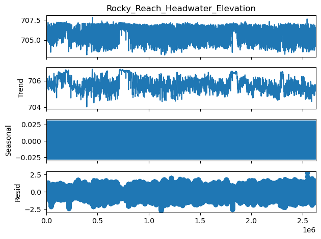

```python
# Perform time series decomposition
series = df['Rocky_Reach_Headwater_Elevation']
result = seasonal_decompose(series, model='additive', period=1825)

# Plot the decomposition
result.plot()
plt.show()
```

# Winter Analysis

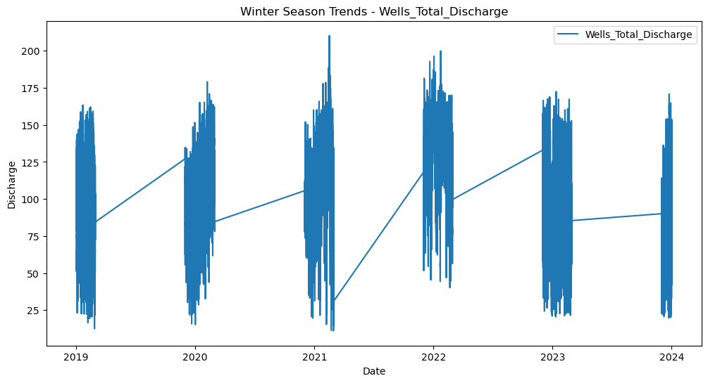

```python
import pandas as pd
import matplotlib.pyplot as plt

df.set_index('datetime_utc', inplace=True)

# Filter the data for the winter season (assuming winter is from December to February)
winter_df = df[(df.index.month >= 12) | (df.index.month <= 2)]

# Plot the time series data
plt.figure(figsize=(12, 6))
plt.plot(winter_df['Wells_Total_Discharge'], label='Wells_Total_Discharge')
plt.title('Winter Season Trends - Wells_Total_Discharge')
plt.xlabel('Date')
plt.ylabel('Discharge')
plt.legend()
plt.show()
```

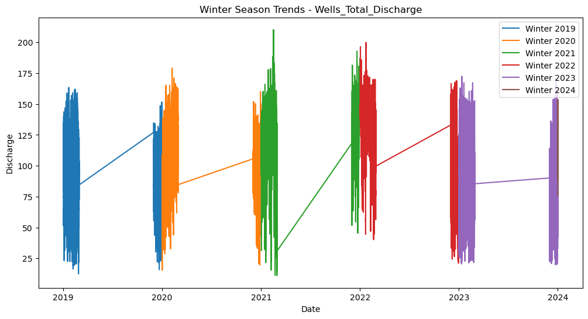

```python
import pandas as pd
import matplotlib.pyplot as plt

# Assuming 'datetime_utc' is present in the columns
# and 'Wells_Total_Discharge' is the column you want to analyze
df.set_index('datetime_utc', inplace=True)

# Extract year and season information
df['Year'] = df.index.year
df['Season'] = (df.index.month % 12 + 3) // 3  # Compute season based on month

# Filter the data for each winter season
winter_df = df[(df['Season'] == 1) & ((df.index.month >= 12) | (df.index.month <= 2))]

# Plot the time series data for each winter season
plt.figure(figsize=(12, 6))
for year in winter_df['Year'].unique():
    year_data = winter_df[winter_df['Year'] == year]
    plt.plot(year_data['Wells_Total_Discharge'], label=f'Winter {year}')

plt.title('Winter Season Trends - Wells_Total_Discharge')
plt.xlabel('Date')
plt.ylabel('Discharge')
plt.legend()
plt.show()
```

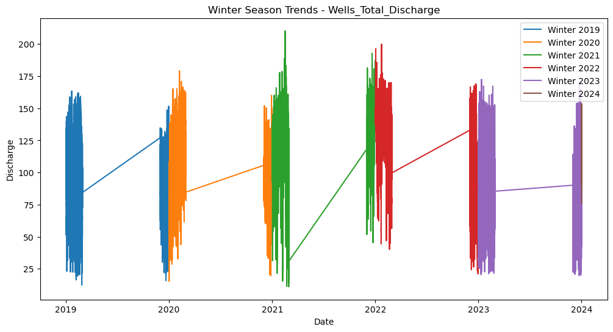

```python
import pandas as pd
import matplotlib.pyplot as plt

# Assuming 'datetime_utc' is present in the columns
# and 'Wells_Total_Discharge' is the column you want to analyze
df.set_index('datetime_utc', inplace=True)

# Extract year and season information
df['Year'] = df.index.year
df['Season'] = (df.index.month // 3 + 1) % 4  # Compute season based on month

# Filter the data for each winter season
winter_df = df[((df.index.month >= 12) | (df.index.month <= 2))]

# Plot the time series data for each winter season
plt.figure(figsize=(12, 6))
for year in winter_df['Year'].unique():
    year_data = winter_df[winter_df['Year'] == year]
    plt.plot(year_data['Wells_Total_Discharge'], label=f'Winter {year}')

plt.title('Winter Season Trends - Wells_Total_Discharge')
plt.xlabel('Date')
plt.ylabel('Discharge')
plt.legend()
plt.show()
```

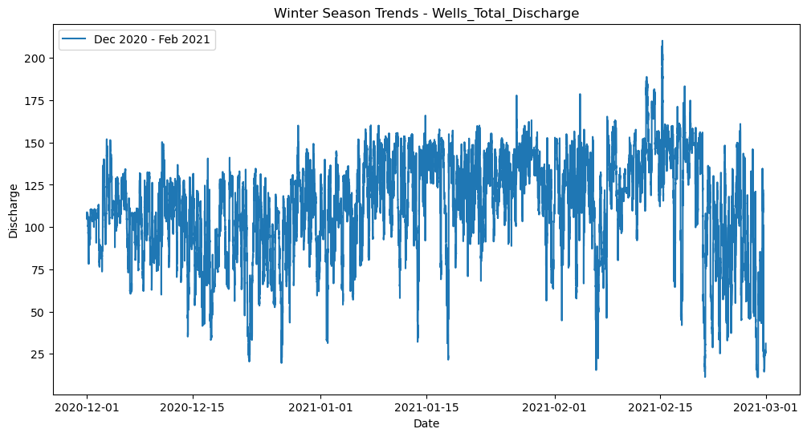

```python
# Read the data from .RDS files
import pyreadr
data =  pyreadr.read_r('2019_1min_df.RDS')
df_2019 = data[None]
data = pyreadr.read_r('2020_1min_df.RDS')
df_2020 = data[None]
data = pyreadr.read_r('2021_1min_df.RDS')
df_2021 = data[None]
data = pyreadr.read_r('2022_1min_df.RDS')
df_2022 = data[None]
data = pyreadr.read_r('2023_1min_df.RDS')
df_2023 = data[None]

# Merge all the dataframes to form one dataframe.
df = pd.concat([df_2019, df_2020, df_2021, df_2022, df_2023], ignore_index=True)
df['datetime_utc'] = pd.to_datetime(df['datetime_utc'])
df.sort_values(by='datetime_utc', inplace=True)
import pandas as pd
import matplotlib.pyplot as plt

# Assuming 'datetime_utc' is present in the columns
# and 'Wells_Total_Discharge' is the column you want to analyze
df.set_index('datetime_utc', inplace=True)

# Extract year and season information
df['Year'] = df.index.year
df['Month'] = df.index.month

# Filter the data for December 2020 to February 2021
selected_period = df[(df['Month'] >= 12) & (df['Year'] == 2020) | (df['Month'] <= 2) & (df['Year'] == 2021)]

# Plot the time series data for the selected period
plt.figure(figsize=(12, 6))
plt.plot(selected_period['Wells_Total_Discharge'], label='Dec 2020 - Feb 2021')

plt.title('Winter Season Trends - Wells_Total_Discharge')
plt.xlabel('Date')
plt.ylabel('Discharge')
plt.legend()
plt.show()
```

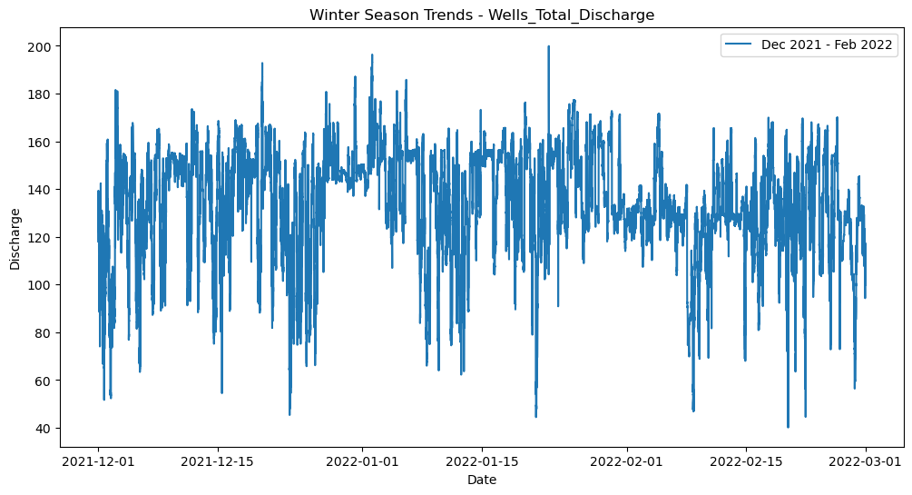

```python
# Read the data from .RDS files
import pyreadr
data =  pyreadr.read_r('2019_1min_df.RDS')
df_2019 = data[None]
data = pyreadr.read_r('2020_1min_df.RDS')
df_2020 = data[None]
data = pyreadr.read_r('2021_1min_df.RDS')
df_2021 = data[None]
data = pyreadr.read_r('2022_1min_df.RDS')
df_2022 = data[None]
data = pyreadr.read_r('2023_1min_df.RDS')
df_2023 = data[None]

# Merge all the dataframes to form one dataframe.
df = pd.concat([df_2019, df_2020, df_2021, df_2022, df_2023], ignore_index=True)
df['datetime_utc'] = pd.to_datetime(df['datetime_utc'])
df.sort_values(by='datetime_utc', inplace=True)

import pandas as pd
import matplotlib.pyplot as plt

df.set_index('datetime_utc', inplace=True)

# Extract year and season information
df['Year'] = df.index.year
df['Month'] = df.index.month

# Filter the data for December 2020 to February 2021
selected_period = df[(df['Month'] >= 12) & (df['Year'] == 2021) | (df['Month'] <= 2) & (df['Year'] == 2022)]

# Plot the time series data for the selected period
plt.figure(figsize=(12, 6))
plt.plot(selected_period['Wells_Total_Discharge'], label='Dec 2021 - Feb 2022')

plt.title('Winter Season Trends - Wells_Total_Discharge')
plt.xlabel('Date')
plt.ylabel('Discharge')
plt.legend()
plt.show()
```

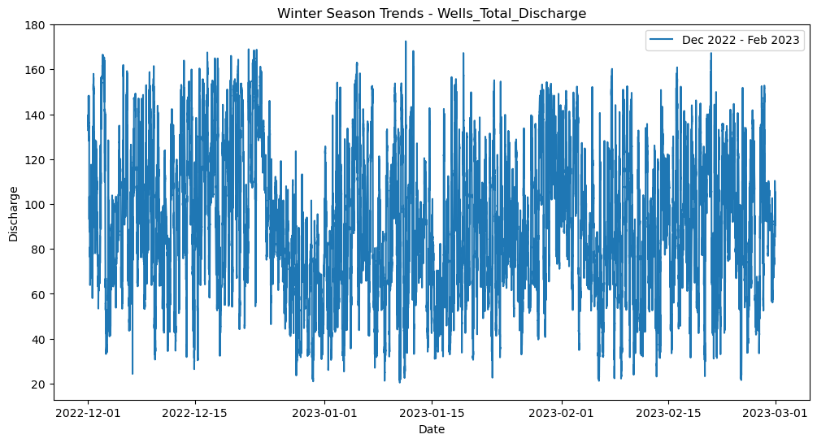

```python
# Read the data from .RDS files
import pyreadr
data =  pyreadr.read_r('2019_1min_df.RDS')
df_2019 = data[None]
data = pyreadr.read_r('2020_1min_df.RDS')
df_2020 = data[None]
data = pyreadr.read_r('2021_1min_df.RDS')
df_2021 = data[None]
data = pyreadr.read_r('2022_1min_df.RDS')
df_2022 = data[None]
data = pyreadr.read_r('2023_1min_df.RDS')
df_2023 = data[None]

# Merge all the dataframes to form one dataframe.
df = pd.concat([df_2019, df_2020, df_2021, df_2022, df_2023], ignore_index=True)
df['datetime_utc'] = pd.to_datetime(df['datetime_utc'])
df.sort_values(by='datetime_utc', inplace=True)

# Fill Null Values using foward fill and backward fill
df.fillna(method='ffill', inplace=True)
df.fillna(method='bfill', inplace=True)
df.columns

import pandas as pd
import matplotlib.pyplot as plt

df.set_index('datetime_utc', inplace=True)

# Extract year and season information
df['Year'] = df.index.year
df['Month'] = df.index.month

# Filter the data for December 2020 to February 2021
selected_period = df[(df['Month'] >= 12) & (df['Year'] == 2022) | (df['Month'] <= 2) & (df['Year'] == 2023)]

# Plot the time series data for the selected period
plt.figure(figsize=(12, 6))
plt.plot(selected_period['Wells_Total_Discharge'], label='Dec 2022 - Feb 2023')

plt.title('Winter Season Trends - Wells_Total_Discharge')
plt.xlabel('Date')
plt.ylabel('Discharge')
plt.legend()
plt.show()
```

# Spring Quarter Analysis Discharge

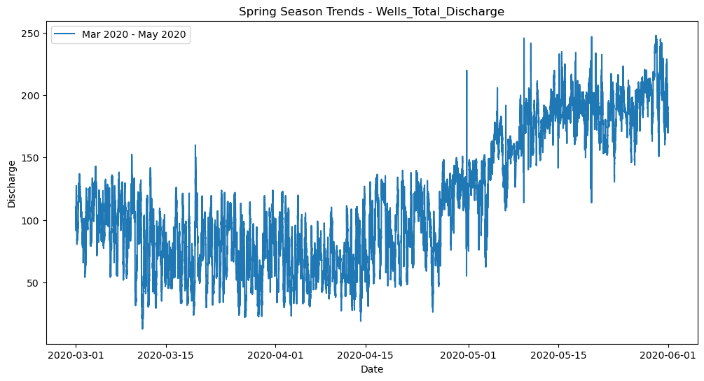

```python
import pandas as pd
import matplotlib.pyplot as plt

# Assuming 'datetime_utc' is present in the columns
# and 'Wells_Total_Discharge' is the column you want to analyze

# Read the data from .RDS files
import pyreadr
data = pyreadr.read_r('2019_1min_df.RDS')
df_2019 = data[None]
data = pyreadr.read_r('2020_1min_df.RDS')
df_2020 = data[None]
data = pyreadr.read_r('2021_1min_df.RDS')
df_2021 = data[None]
data = pyreadr.read_r('2022_1min_df.RDS')
df_2022 = data[None]
data = pyreadr.read_r('2023_1min_df.RDS')
df_2023 = data[None]

# Merge all the dataframes to form one dataframe.
df = pd.concat([df_2019, df_2020, df_2021, df_2022, df_2023], ignore_index=True)
df['datetime_utc'] = pd.to_datetime(df['datetime_utc'])
df.sort_values(by='datetime_utc', inplace=True)

# Fill Null Values using forward fill and backward fill
df.fillna(method='ffill', inplace=True)
df.fillna(method='bfill', inplace=True)

# Set the index to 'datetime_utc'
df.set_index('datetime_utc', inplace=True)

# Extract year and season information
df['Year'] = df.index.year
df['Month'] = df.index.month

# Filter the data for March to May 2020 (Spring 2020)
selected_period = df[((df['Month'] >= 3) & (df['Year'] == 2020)) & (df['Month'] <= 5)]

# Plot the time series data for the selected period
plt.figure(figsize=(12, 6))
plt.plot(selected_period['Wells_Total_Discharge'], label='Mar 2020 - May 2020')

plt.title('Spring Season Trends - Wells_Total_Discharge')
plt.xlabel('Date')
plt.ylabel('Discharge')
plt.legend()
plt.show()
```

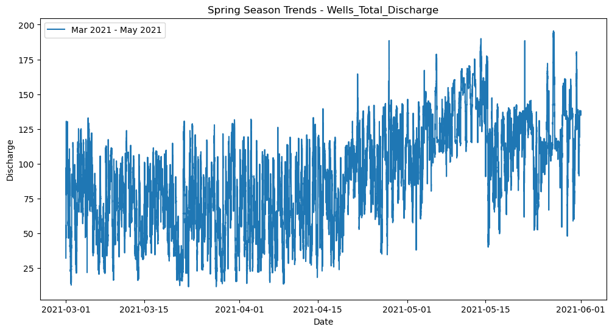

```python
import pandas as pd
import matplotlib.pyplot as plt



# Read the data from .RDS files
import pyreadr
data = pyreadr.read_r('2019_1min_df.RDS')
df_2019 = data[None]
data = pyreadr.read_r('2020_1min_df.RDS')
df_2020 = data[None]
data = pyreadr.read_r('2021_1min_df.RDS')
df_2021 = data[None]
data = pyreadr.read_r('2022_1min_df.RDS')
df_2022 = data[None]
data = pyreadr.read_r('2023_1min_df.RDS')
df_2023 = data[None]

# Merge all the dataframes to form one dataframe.
df = pd.concat([df_2019, df_2020, df_2021, df_2022, df_2023], ignore_index=True)
df['datetime_utc'] = pd.to_datetime(df['datetime_utc'])
df.sort_values(by='datetime_utc', inplace=True)

# Fill Null Values using forward fill and backward fill
df.fillna(method='ffill', inplace=True)
df.fillna(method='bfill', inplace=True)

# Set the index to 'datetime_utc'
df.set_index('datetime_utc', inplace=True)

# Extract year and season information
df['Year'] = df.index.year
df['Month'] = df.index.month

# Filter the data for March to May 2020 (Spring 2020)
selected_period = df[((df['Month'] >= 3) & (df['Year'] == 2021)) & (df['Month'] <= 5)]

# Plot the time series data for the selected period
plt.figure(figsize=(12, 6))
plt.plot(selected_period['Wells_Total_Discharge'], label='Mar 2021 - May 2021')

plt.title('Spring Season Trends - Wells_Total_Discharge')
plt.xlabel('Date')
plt.ylabel('Discharge')
plt.legend()
plt.show()
```

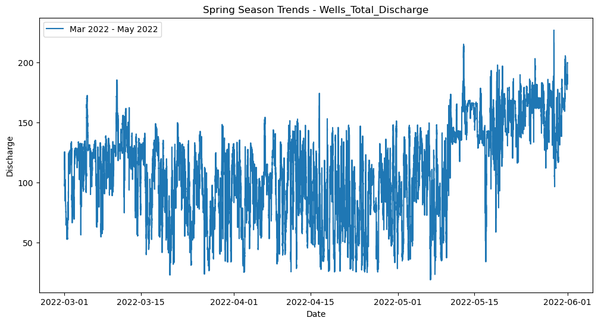

```python
import pandas as pd
import matplotlib.pyplot as plt


# Read the data from .RDS files
import pyreadr
data = pyreadr.read_r('2019_1min_df.RDS')
df_2019 = data[None]
data = pyreadr.read_r('2020_1min_df.RDS')
df_2020 = data[None]
data = pyreadr.read_r('2021_1min_df.RDS')
df_2021 = data[None]
data = pyreadr.read_r('2022_1min_df.RDS')
df_2022 = data[None]
data = pyreadr.read_r('2023_1min_df.RDS')
df_2023 = data[None]

# Merge all the dataframes to form one dataframe.
df = pd.concat([df_2019, df_2020, df_2021, df_2022, df_2023], ignore_index=True)
df['datetime_utc'] = pd.to_datetime(df['datetime_utc'])
df.sort_values(by='datetime_utc', inplace=True)

# Fill Null Values using forward fill and backward fill
df.fillna(method='ffill', inplace=True)
df.fillna(method='bfill', inplace=True)

# Set the index to 'datetime_utc'
df.set_index('datetime_utc', inplace=True)

# Extract year and season information
df['Year'] = df.index.year
df['Month'] = df.index.month

# Filter the data for March to May 2020 (Spring 2020)
selected_period = df[((df['Month'] >= 3) & (df['Year'] == 2022)) & (df['Month'] <= 5)]

# Plot the time series data for the selected period
plt.figure(figsize=(12, 6))
plt.plot(selected_period['Wells_Total_Discharge'], label='Mar 2022 - May 2022')

plt.title('Spring Season Trends - Wells_Total_Discharge')
plt.xlabel('Date')
plt.ylabel('Discharge')
plt.legend()
plt.show()
```

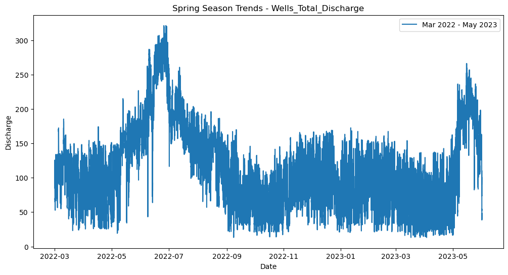

```python
import pandas as pd
import matplotlib.pyplot as plt


# Read the data from .RDS files
import pyreadr
data =  pyreadr.read_r('2019_1min_df.RDS')
df_2019 = data[None]
data = pyreadr.read_r('2020_1min_df.RDS')
df_2020 = data[None]
data = pyreadr.read_r('2021_1min_df.RDS')
df_2021 = data[None]
data = pyreadr.read_r('2022_1min_df.RDS')
df_2022 = data[None]
data = pyreadr.read_r('2023_1min_df.RDS')
df_2023 = data[None]

# Merge all the dataframes to form one dataframe.
df = pd.concat([df_2019, df_2020, df_2021, df_2022, df_2023], ignore_index=True)
df['datetime_utc'] = pd.to_datetime(df['datetime_utc'])
df.sort_values(by='datetime_utc', inplace=True)

# Fill Null Values using forward fill and backward fill
df.fillna(method='ffill', inplace=True)
df.fillna(method='bfill', inplace=True)

# Set the index to 'datetime_utc'
df.set_index('datetime_utc', inplace=True)

# Extract year and season information
df['Year'] = df.index.year
df['Month'] = df.index.month

# Filter the data for March 2022 to May 2023 (Spring)
selected_period = df[((df['Month'] >= 3) & (df['Year'] == 2022)) | ((df['Month'] <= 5) & (df['Year'] == 2023))]

# Plot the time series data for the selected period
plt.figure(figsize=(12, 6))
plt.plot(selected_period['Wells_Total_Discharge'], label='Mar 2022 - May 2023')

plt.title('Spring Season Trends - Wells_Total_Discharge')
plt.xlabel('Date')
plt.ylabel('Discharge')
plt.legend()
plt.show()
```

# Boat Launch

```python
# Read the data from .RDS files
import pyreadr
data =  pyreadr.read_r('2019_boat_launch_1min_df.RDS')
df_2019_boat = data[None]
data = pyreadr.read_r('2020_boat_launch_1min_df.RDS')
df_2020_boat = data[None]
data = pyreadr.read_r('2021_boat_launch_1min_df.RDS')
df_2021_boat = data[None]
data = pyreadr.read_r('2022_boat_launch_1min_df.RDS')
df_2022_boat = data[None]
data = pyreadr.read_r('2023_boat_launch_1min_df.RDS')
df_2023_boat = data[None]
```

```python
# Merge all the dataframes to form one dataframe.
df_boat = pd.concat([df_2019_boat, df_2020_boat, df_2021_boat, df_2022_boat, df_2023_boat], ignore_index=True)
df_boat.shape
```

```
(2629440, 11)
```

```python
df_boat.isna().sum()
```

```
datetime_utc                    0
datetime_stamp                  0
KirbyBillingsley_462.9      59360
Riverfront_466.2              348
Confluence_468.8              315
LincolnRock_474.3         1818164
Orondo_483.4              1845598
Entiat_484.0              1845596
Daroga_487.7              1845591
ChelanFalls_502.8         1789219
BeebeBridge_503.7         1789207
dtype: int64
```

```python
# Fill Null Values using foward fill and backward fill
df_boat.fillna(method='ffill', inplace=True)
df_boat.fillna(method='bfill', inplace=True)
```

```python
df_boat.isna().sum()
```

```
datetime_utc              0
datetime_stamp            0
KirbyBillingsley_462.9    0
Riverfront_466.2          0
Confluence_468.8          0
LincolnRock_474.3         0
Orondo_483.4              0
Entiat_484.0              0
Daroga_487.7              0
ChelanFalls_502.8         0
BeebeBridge_503.7         0
dtype: int64
```

```python
df_boat.head()
```

|  | datetime_utc | datetime_stamp | KirbyBillingsley_462.9 | Riverfront_466.2 | Confluence_468.8 | LincolnRock_474.3 | Orondo_483.4 | Entiat_484.0 | Daroga_487.7 | ChelanFalls_502.8 | BeebeBridge_503.7 |
| --- | --- | --- | --- | --- | --- | --- | --- | --- | --- | --- | --- |
| 0 | 2019-01-01T08:00:00Z | 2019-01-01 08:00:00 | 613.715984 | 613.813415 | 614.330208 | 598.500058 | 701.999944 | 700.999939 | 700.000053 | 550.000122 | 500.000125 |
| 1 | 2019-01-01T08:01:00Z | 2019-01-01 08:01:00 | 613.710962 | 613.803742 | 614.317896 | 598.500058 | 701.999944 | 700.999939 | 700.000053 | 550.000122 | 500.000125 |
| 2 | 2019-01-01T08:02:00Z | 2019-01-01 08:02:00 | 613.705940 | 613.794069 | 614.305584 | 598.500058 | 701.999944 | 700.999939 | 700.000053 | 550.000122 | 500.000125 |
| 3 | 2019-01-01T08:03:00Z | 2019-01-01 08:03:00 | 613.700918 | 613.784396 | 614.293272 | 598.500058 | 701.999944 | 700.999939 | 700.000053 | 550.000122 | 500.000125 |
| 4 | 2019-01-01T08:04:00Z | 2019-01-01 08:04:00 | 613.695896 | 613.774723 | 614.280960 | 598.500058 | 701.999944 | 700.999939 | 700.000053 | 550.000122 | 500.000125 |

```python
df_boat.columns
```

```
Index(['datetime_utc', 'datetime_stamp', 'KirbyBillingsley_462.9',
       'Riverfront_466.2', 'Confluence_468.8', 'LincolnRock_474.3',
       'Orondo_483.4', 'Entiat_484.0', 'Daroga_487.7', 'ChelanFalls_502.8',
       'BeebeBridge_503.7'],
      dtype='object')
```

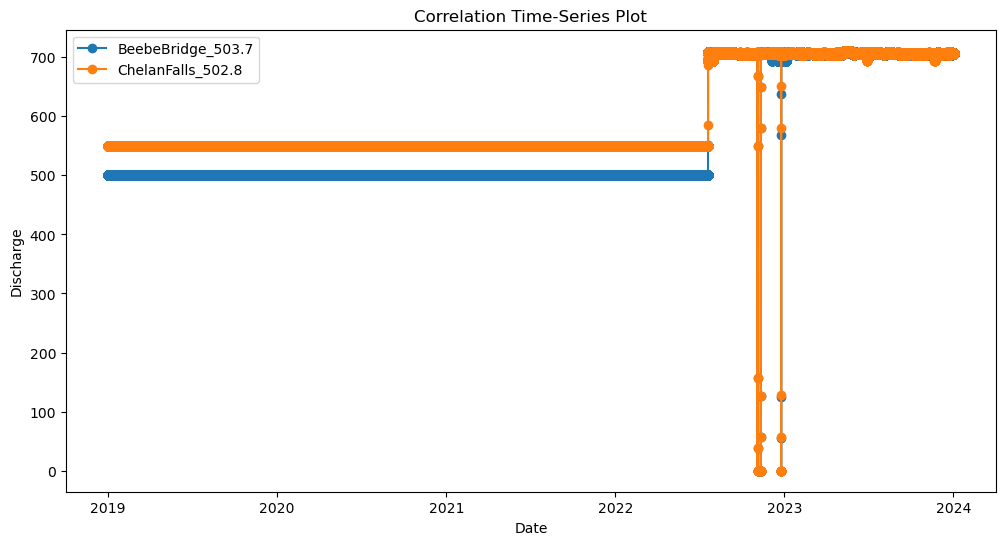

```python
df_boat['datetime_utc'] = pd.to_datetime(df_boat['datetime_utc'])
df_boat.sort_values(by='datetime_utc', inplace=True)

# Plot correlation time-series for 'BeebeBridge_503.7' and 'ChelanFalls_502.8'
plt.figure(figsize=(12, 6))
plt.plot(df_boat['datetime_utc'], df_boat['BeebeBridge_503.7'], label='BeebeBridge_503.7', linestyle='-', marker='o')
plt.plot(df_boat['datetime_utc'], df_boat['ChelanFalls_502.8'], label='ChelanFalls_502.8', linestyle='-', marker='o')

plt.title('Correlation Time-Series Plot')
plt.xlabel('Date')
plt.ylabel('Discharge')
plt.legend()
plt.show()
```

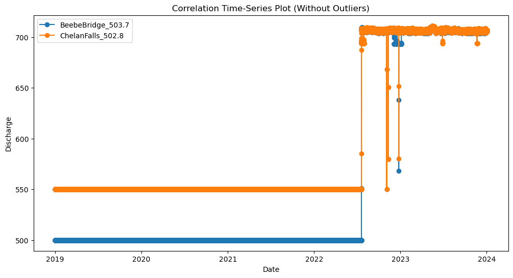

```python
import pandas as pd
import matplotlib.pyplot as plt
from scipy.stats import zscore

#'BeebeBridge_503.7' and 'ChelanFalls_502.8'
df_boat = pd.concat([df_2019_boat, df_2020_boat, df_2021_boat, df_2022_boat, df_2023_boat], ignore_index=True)
df_boat['datetime_utc'] = pd.to_datetime(df_boat['datetime_utc'])
df_boat.sort_values(by='datetime_utc', inplace=True)

# Fill Null Values using foward fill and backward fill
df_boat.fillna(method='ffill', inplace=True)
df_boat.fillna(method='bfill', inplace=True)

# Calculate Z-scores for 'BeebeBridge_503.7' and 'ChelanFalls_502.8'
z_scores_beebebridge = zscore(df_boat['BeebeBridge_503.7'])
z_scores_chelanfalls = zscore(df_boat['ChelanFalls_502.8'])

# Set a threshold for considering a point as an outlier (e.g., z-score > 3)
# best for middle averages to rid outliers
outlier_threshold = 3

# Remove outliers based on the threshold
df_boat = df_boat[(abs(z_scores_beebebridge) < outlier_threshold) & (abs(z_scores_chelanfalls) < outlier_threshold)]

# Plot correlation time-series for 'BeebeBridge_503.7' and 'ChelanFalls_502.8' without outliers
plt.figure(figsize=(12, 6))
plt.plot(df_boat['datetime_utc'], df_boat['BeebeBridge_503.7'], label='BeebeBridge_503.7', linestyle='-', marker='o')
plt.plot(df_boat['datetime_utc'], df_boat['ChelanFalls_502.8'], label='ChelanFalls_502.8', linestyle='-', marker='o')

plt.title('Correlation Time-Series Plot (Without Outliers)')
plt.xlabel('Date')
plt.ylabel('Discharge')
plt.legend()
plt.show()
```

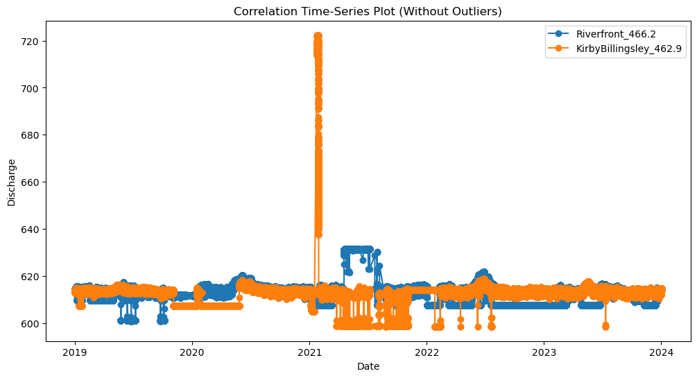

```python
import pandas as pd
import matplotlib.pyplot as plt
from scipy.stats import zscore

#'Riverfront_466.2' and 'KirbyBillingsley_462.9' are the columns to analyze
df_boat = pd.concat([df_2019_boat, df_2020_boat, df_2021_boat, df_2022_boat, df_2023_boat], ignore_index=True)
df_boat['datetime_utc'] = pd.to_datetime(df_boat['datetime_utc'])
df_boat.sort_values(by='datetime_utc', inplace=True)

# Fill Null Values using foward fill and backward fill
df_boat.fillna(method='ffill', inplace=True)
df_boat.fillna(method='bfill', inplace=True)

# Calculate Z-scores for 'Riverfront_466.2' and 'KirbyBillingsley_462.9'
z_scores_riverfront = zscore(df_boat['Riverfront_466.2'])
z_scores_kirbybillingsley = zscore(df_boat['KirbyBillingsley_462.9'])

# Set a threshold for considering a point as an outlier (e.g., z-score > 3)
outlier_threshold = 3

# Remove outliers based on the threshold
df_boat = df_boat[(abs(z_scores_riverfront) < outlier_threshold) & (abs(z_scores_kirbybillingsley) < outlier_threshold)]

# Plot correlation time-series for 'Riverfront_466.2' and 'KirbyBillingsley_462.9' without outliers
plt.figure(figsize=(12, 6))
plt.plot(df_boat['datetime_utc'], df_boat['Riverfront_466.2'], label='Riverfront_466.2', linestyle='-', marker='o')
plt.plot(df_boat['datetime_utc'], df_boat['KirbyBillingsley_462.9'], label='KirbyBillingsley_462.9', linestyle='-', marker='o')

plt.title('Correlation Time-Series Plot (Without Outliers)')
plt.xlabel('Date')
plt.ylabel('Discharge')
plt.legend()
plt.show()
```